# Simple Linear Regression - Week 9, Lecture 1

Author

Hector Gavilanes

**An online retailer needs to manage the amount of time needed to select the ordered items and assemble them for shipping. In order to assess the amount of time (Time) his assemblers devote to this task, the retailer takes a random sample of 100 orders and records the number of items in each order (Noltems) and the time needed to assemble the shipment. The data are given here: [Google Sheet](https://docs.google.com/spreadsheets/d/1xAsE0KmspC0dP4Uuyym33uU1G8ahI6z7wPVwts7BTRM/edit?usp=sharing).**

## Libraries

```r
library(tidyverse)
library(gsheet)
library(car)
library(gridExtra)
```

## Data

```r
# clear environment
rm(list = ls())

# extract data
data <- as_tibble(gsheet2tbl("https://docs.google.com/spreadsheets/d/1xAsE0KmspC0dP4Uuyym33uU1G8ahI6z7wPVwts7BTRM/edit?usp=sharing"))
```

1. Summarize the data using appropriate summary statistics.

```r
summary(data$Time)
```

```
   Min. 1st Qu.  Median    Mean 3rd Qu.    Max.
   2.40   18.05   24.85   27.14   34.83   57.10
```

2. Model the amount of time as a function of the number of items in the order.

```r
m1 = data$Time ~ data$NoItems
time_model <- lm(m1)
summary(time_model)
```

```
Call:
lm(formula = m1)

Residuals:
     Min       1Q   Median       3Q      Max
-13.2501  -2.6543   0.5965   3.0008   9.0198

Coefficients:
             Estimate Std. Error t value Pr(>|t|)
(Intercept)  14.58510    0.65928   22.12   <2e-16 ***
data$NoItems  1.06505    0.04142   25.71   <2e-16 ***
---
Signif. codes:  0 '***' 0.001 '**' 0.01 '*' 0.05 '.' 0.1 ' ' 1

Residual standard error: 4.428 on 98 degrees of freedom
Multiple R-squared:  0.8709,    Adjusted R-squared:  0.8696
F-statistic:   661 on 1 and 98 DF,  p-value: < 2.2e-16
```

## Model formula:

$$\hat{y} = 14.59 + 1.07{\text{ items}}$$

### Interpretation

```r
confint(time_model)
```

```
                  2.5 %    97.5 %
(Intercept)  13.2767827 15.893416
data$NoItems  0.9828406  1.147253
```

The 95% CI for $\beta_{items}$ is (0.98, 1.15)

4. Use the appropriate hypothesis test to determine if the number of items in the order is a significant predictor of the amount of time to pick and ship the order. Test at the $\alpha=0.05$ level.

### Hypotheses

- $H_0: \beta_{items} = 0$
- $H_1: \beta_{items} \ne 0$

### Test Statistic

- $t_{0} = 25.71$

### p-Value

- $p < 0.001$

## Conclusion

Reject $H_0$ at $\alpha = 0.05$. There is sufficient evidence to suggest that the number of items is a significant predictor for shipment time.

5. State and assess the assumptions of linear regression. Is our model valid?

### Assumptions

$\varepsilon \overset{\text{iid}}{\sim} N(0, \sigma^2)$

The **residuals** follow a normal distribution.

- Normality is checked with the histogram and/or qq plot.
  - Mean $\mu=0$
- Variance is checked with the scatter plot and/or the Brown-Forsythe-Levene.
  - Common variance $\sigma^2$

### Assessment

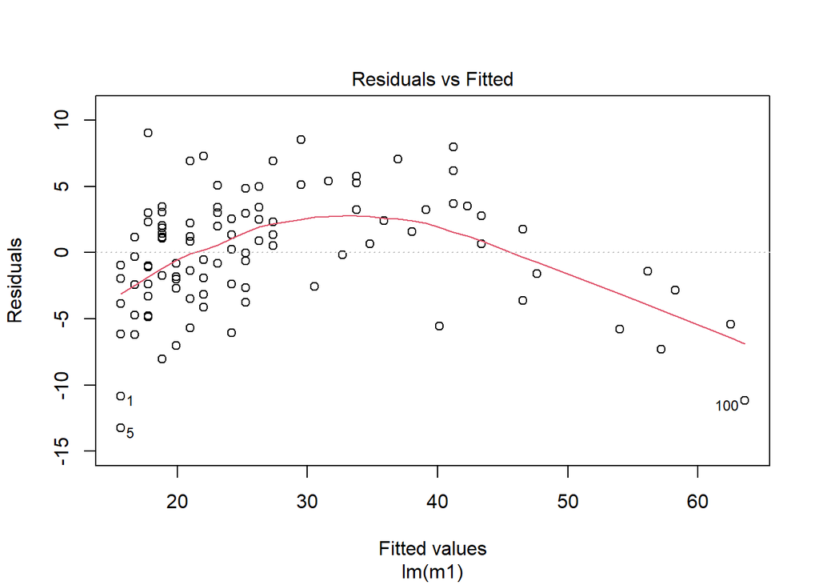

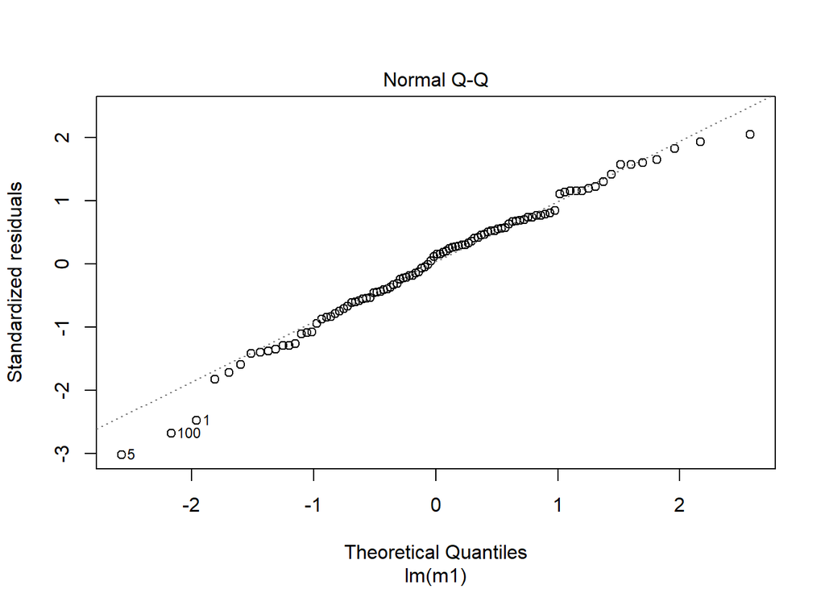

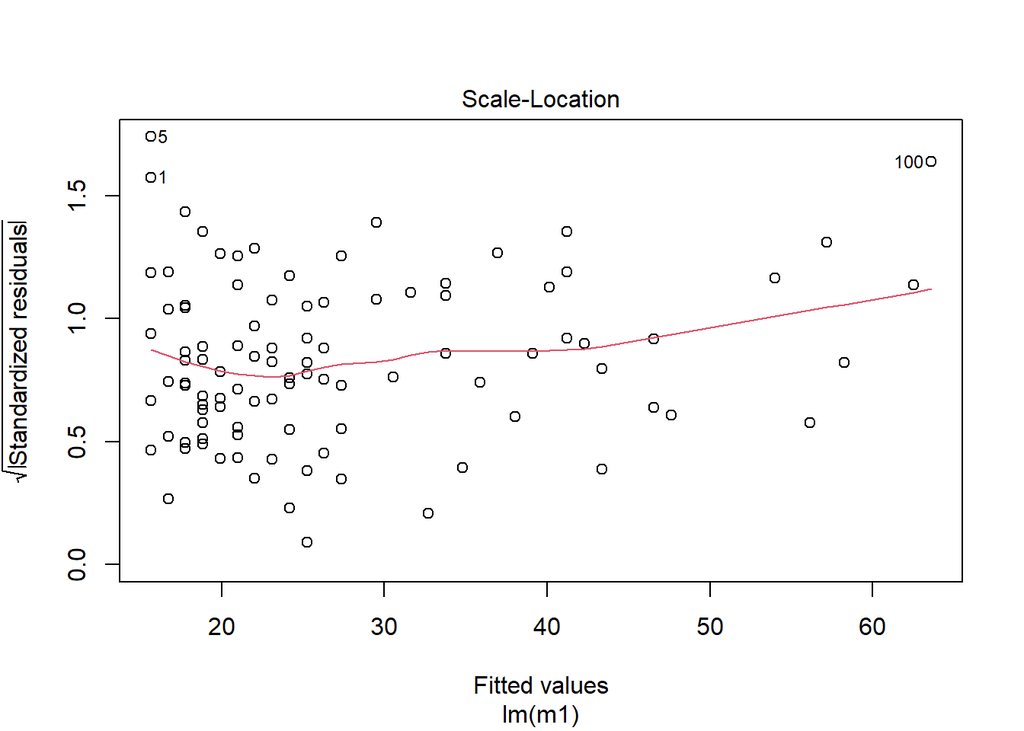

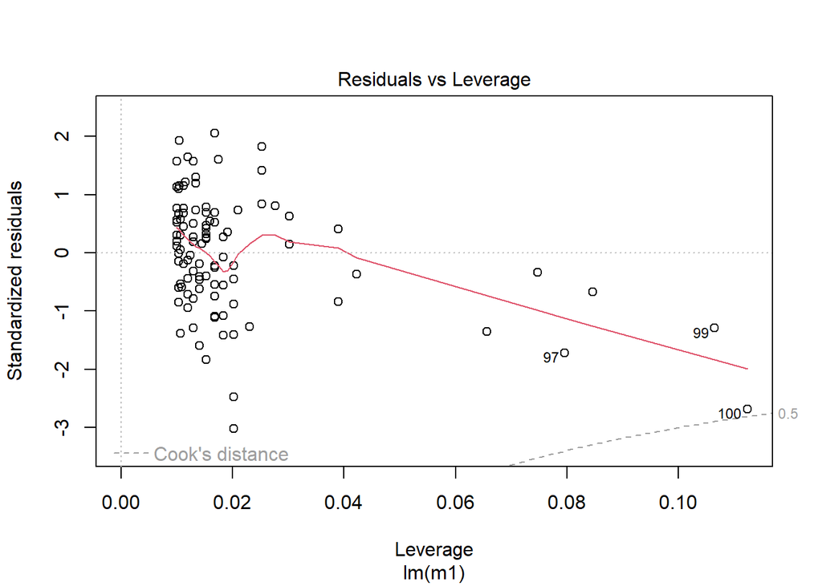

```r
# Assessment of Residuals
plot(time_model)
```

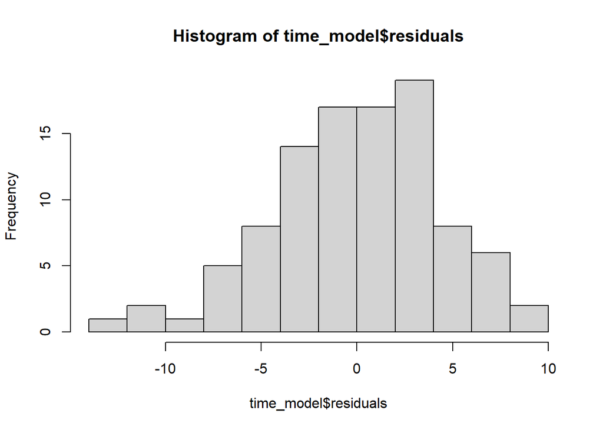

```r
# histogram residuals
hist(time_model$residuals)
```

However, the variance test is not suitable for this case because both are continuous variables.

6. Find Pearson’s correlation between the amount of time and the number of items and the corresponding 95% confidence interval.

```r
# parametric correlation method to find coefficient
cor.test(data$Time, data$NoItems,
         use = "complete.obs")
```

```
    Pearson's product-moment correlation

data:  data$Time and data$NoItems
t = 25.71, df = 98, p-value < 2.2e-16
alternative hypothesis: true correlation is not equal to 0
95 percent confidence interval:
 0.9021612 0.9546449
sample estimates:
      cor
0.9332132
```

- The 95% CI for $\rho$ is (0.90, 0.95).
7. Find Spearman’s correlation between the amount of time and the number of items and the corresponding 95% confidence interval.

```r
# nonparametric correlation method to find coefficient
cor(data$Time, data$NoItems,
    use = "complete.obs",
    method = "spearman")
```

```
[1] 0.9311364
```

8. State and assess the assumptions for Pearson’s correlation. Is Pearson’s correlation valid for this data?

### Pearson’s Correlation Assumptions

The assumption on Pearson’s correlation is that both variables are normally distributed.

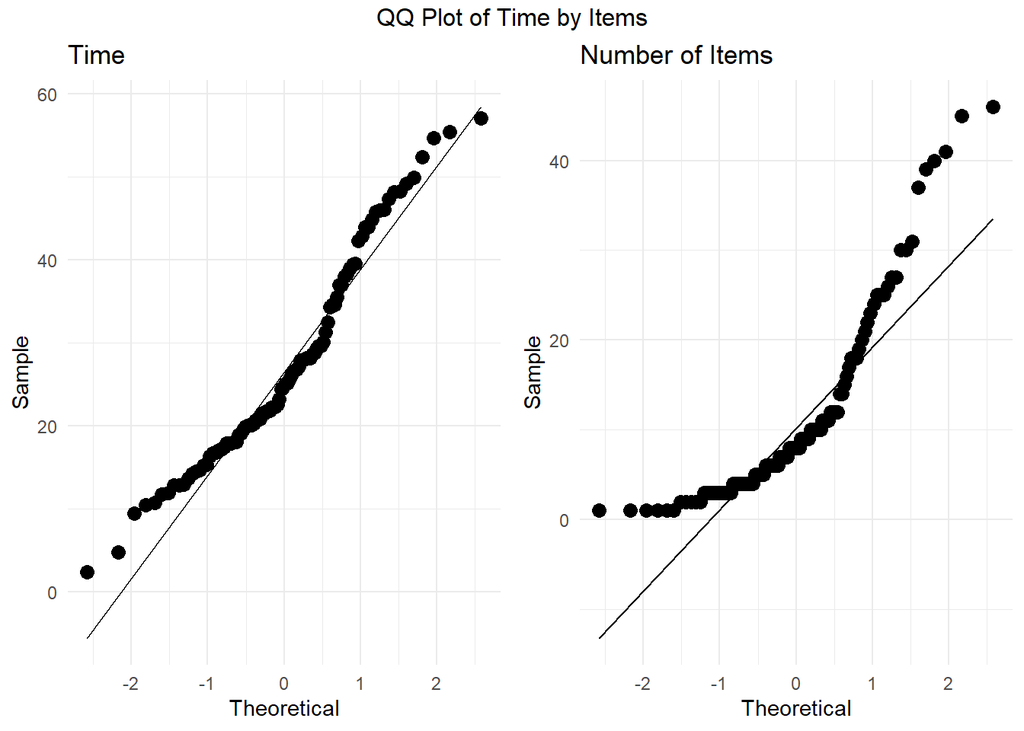

```r
# QQ plot: Time
qq_time <- data %>%
  ggplot(aes(sample = Time)) +
    stat_qq(size=3) +
    stat_qq_line() +
    theme_minimal() +
    xlab("Theoretical") +
    ylab("Sample")+
  labs(title = "Time")

# QQ plot: Items
qq_items <- data %>%
  ggplot(aes(sample = NoItems)) +
    stat_qq(size=3) +
    stat_qq_line() +
    theme_minimal() +
    xlab("Theoretical") +
    ylab("Sample")+
  labs(title = "Number of Items")

# Combine both graphs
grid.arrange(qq_time, qq_items, nrow=1, top = "QQ Plot of Time by Items")
```

- The Pearson’s correlation assumptions have not been met. The *Number of Items* variable is not normally distributed. Thus, the nonparametric Spearman’s correlation test should be reported.

### Spearman’s Correlation

- $\rho$ = 0.931 indicates a very strong correlation.
- It is a positive correlation; as *Number of Items* increases, *Shipping Time* increases
9. Construct a visualization for the model. At the very least, you should have a scatterplot with a regression line overlaid.

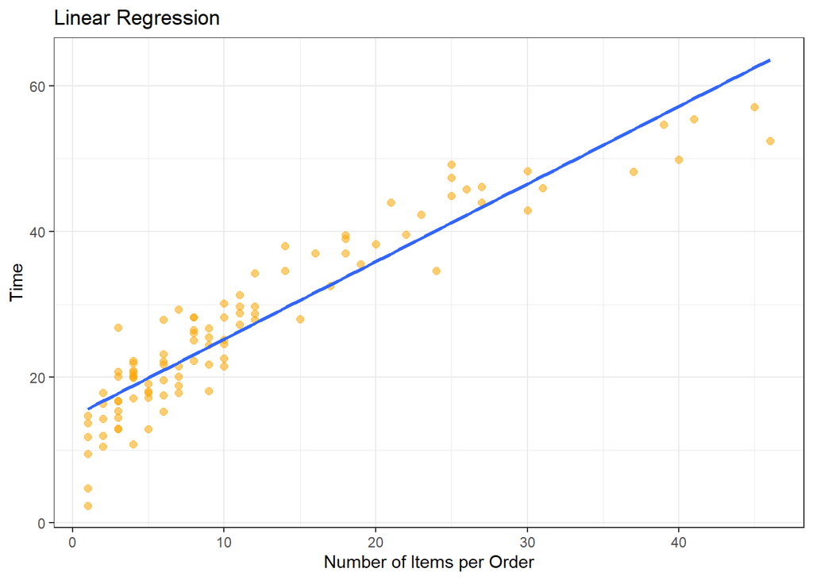

```r
data %>%
  ggplot(aes(x = NoItems, y = Time))+
  geom_point(size=2, alpha=0.55, colour="orange")+
  geom_smooth(formula = y ~ x, method=lm, se=FALSE)+
  theme_bw()+
  labs(title = "Linear Regression",
       x = "Number of Items per Order")
```

```r
time_coef <- time_model$coefficients
time_coef
```

```
 (Intercept) data$NoItems
   14.585099     1.065047
```

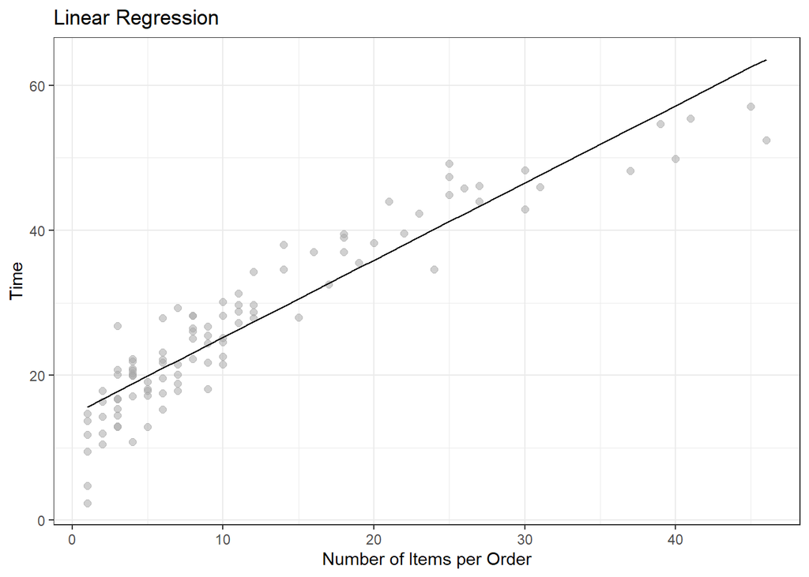

```r
data <- data %>%
  mutate(y_hat = time_coef[1] + time_coef[2] * data$NoItems)

data %>%
  ggplot(aes(x = NoItems, y = Time))+
  geom_point(size=2, alpha=0.55, colour="darkgray")+
  geom_line(aes(y = y_hat))+
  theme_bw()+
  labs(title = "Linear Regression",
       x = "Number of Items per Order")
```